# Associative Baseline Models (Reduced)

Project Team

```r
required_pkgs <- c("dplyr", "tidyr", "arrow", "broom", "knitr", "readr")
missing_pkgs <- required_pkgs[!vapply(required_pkgs, requireNamespace, logical(1), quietly = TRUE)]
if (length(missing_pkgs) > 0) stop("Missing packages: ", paste(missing_pkgs, collapse = ", "))

library(dplyr)
library(tidyr)
library(arrow)
library(broom)
library(knitr)
library(readr)
library(car)
library(ggplot2)
```

## 1) Purpose, Setup, and Modeling Strategy

This section presents a reduced associative model for stop-level arrival delay. Our goal here is interpretability rather than prediction. We began with a broader set of candidate predictors and then trimmed the model step by step to reduce redundancy, check multicollinearity, and retain a smaller set of meaningful variables.

We first define the modeling inputs, outcome variable, and candidate predictor set used as the starting point for the reduced associative model.

```r
set.seed(7900)

input_parquet <- "E:/MUSA/8010practicum/outputs/direct_pipeline_final_20260327/baseline_modeling_table_final_direct.parquet"
output_dir <- "E:/MUSA/8010practicum/outputs/direct_pipeline_final_20260327/associative_baseline_models_20260404"
dir.create(output_dir, recursive = TRUE, showWarnings = FALSE)

outcome_cont <- "lateness_vs_original_schedule_min"


# Weekly local-time-slot imputation:
# interpreted as a 7-day centered window (±3 days) by local trip date.
week_window_days <- 3

candidate_predictors <- c(
  "route_id", "direction", "stop_sequence", "prev_stop_sched_hour", "prev_stop_sched_hour_group",
  "schedule_season", "schedule_daytype", "vessel_trip_seq_in_chain", "vessel_capacity",
  "is_terminal_stop", "prev_stop_shared_stop_flag", "curr_stop_shared_stop_flag",
  "planned_turnaround_gap_min", "scheduled_headway_min", "expected_water_min",
  "prev_stop_sequence", "prev_stop_boardings", "prev_stop_alightings", "prev_stop_onboard",
  "prev_stop_load_factor", "env_temperature_c", "env_wind_speed_mps", "env_visibility_m",
  "env_precipitation_mm", "env_battery_water_level_anomaly", "env_narrows_current_residual",
  "env_battery_water_level_obs", "env_narrows_current_obs",
  "prev_stop_hourly_vessel_count_all", "curr_stop_hourly_vessel_count_all"
)
prior_delay_predictors <- c("inherited_prev_trip_delay", "carried_within_trip_delay")
```

## 2) Data Loading and Variable Setup

We use the stop-level baseline modeling table as the input dataset for the associative model. The continuous outcome is stop-level arrival lateness in minutes relative to the original schedule. At this stage, we define a broad candidate set of predictors spanning route and schedule context, stop and vessel operations, ridership and load conditions, environmental conditions, and prior-delay terms. This set serves as the starting point for subsequent feature screening and trimming.

The initial candidate predictors were grouped into five broad categories: route and schedule context; stop and vessel operations; ridership and load conditions; environmental conditions; and prior-delay indicators.

## 3) AIS and Environmental Variable Imputation

Missing values in AIS and environmental variables were imputed using a local time-slot rolling rule. We first used observations from the same scheduled hour within a centered 7-day window. When those values were unavailable, we then fell back to the same scheduled hour group. This step was used to preserve candidate predictors for the associative model before feature screening and model reduction.

## 4) Helper Functions

## 5) Correlation Screening and Initial Feature Trimming

Before fitting the reduced associative models, we examined correlations among candidate numeric predictors to identify redundancy in the initial feature set. The correlation matrix served as a first-pass screening tool: when predictors conveyed highly similar information, we prioritized variables that were more interpretable and operationally meaningful. This step informed the initial trimming of the associative model before formal multicollinearity diagnostics.

```r
numeric_candidate_predictors <- intersect(
  candidate_predictors,
  names(df_imp)[sapply(df_imp, is.numeric)]
)

corr_vars <- df_imp %>%
  select(all_of(numeric_candidate_predictors)) %>%
  select(where(~ !all(is.na(.))))

corr_matrix <- cor(corr_vars, use = "pairwise.complete.obs")
```

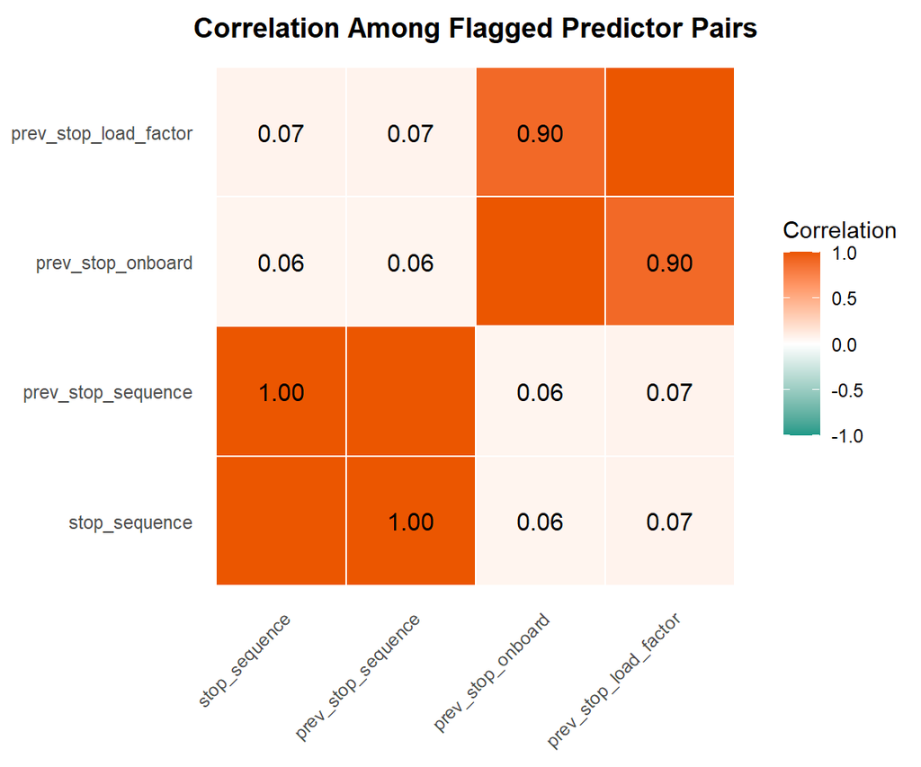

```r
focus_vars <- c(
  "stop_sequence",
  "prev_stop_sequence",
  "prev_stop_onboard",
  "prev_stop_load_factor"
)


focus_corr <- corr_matrix[focus_vars, focus_vars]

focus_plot_df <- as.data.frame(as.table(focus_corr)) %>%
  rename(var1 = Var1, var2 = Var2, corr = Freq) %>%
  mutate(label = ifelse(var1 == var2, "", sprintf("%.2f", corr)))

focus_plot <- ggplot(focus_plot_df, aes(x = var1, y = var2, fill = corr)) +
  geom_tile(color = "white", linewidth = 0.5) +
  geom_text(aes(label = label), size = 4) +
  scale_fill_gradient2(
    low = "#1A9988", mid = "white", high = "#EB5600",
    midpoint = 0,
    limits = c(-1, 1)
  ) +
  coord_fixed() +
  theme_minimal() +
  theme(
    panel.grid = element_blank(),
    axis.text.x = element_text(angle = 45, hjust = 1),
    plot.title = element_text(size = 13, face = "bold", hjust = 0.5)
  ) +
  labs(
    title = "Correlation Among Flagged Predictor Pairs",
    x = NULL,
    y = NULL,
    fill = "Correlation"
  )

focus_plot
```

```r
corr_pairs <- as.data.frame(as.table(corr_matrix)) %>%
  rename(var1 = Var1, var2 = Var2, corr = Freq) %>%
  filter(var1 != var2) %>%
  mutate(abs_corr = abs(corr)) %>%
  filter(abs_corr >= 0.7) %>%
  rowwise() %>%
  mutate(pair_id = paste(sort(c(var1, var2)), collapse = " || ")) %>%
  ungroup() %>%
  distinct(pair_id, .keep_all = TRUE) %>%
  arrange(desc(abs_corr)) %>%
  select(var1, var2, corr, abs_corr)

corr_pairs %>%
  head(20) %>%
  kable(caption = "Highly correlated candidate predictor pairs (|r| >= 0.7)")
```

Highly correlated candidate predictor pairs (|r| >= 0.7)

| var1 | var2 | corr | abs_corr |
| --- | --- | --- | --- |
| prev_stop_sequence | stop_sequence | 1.0000000 | 1.0000000 |
| prev_stop_load_factor | prev_stop_onboard | 0.8965757 | 0.8965757 |

The correlation matrix was used as a first-pass screening tool for feature trimming. Using a threshold of |r| >= 0.7, we identified two highly redundant predictor pairs: prev_stop_sequence with stop_sequence (r = 1.00), and prev_stop_load_factor with prev_stop_onboard (r = 0.90). These pairs suggested overlapping information, so one variable from each pair was flagged for removal before proceeding to VIF-based multicollinearity diagnostics.

Based on these results, we retained stop_sequence and dropped prev_stop_sequence because both variables represented the same progression along the route, but stop_sequence was more direct to interpret. We also retained prev_stop_onboard and dropped prev_stop_load_factor, since both captured passenger load conditions, but onboard passenger count was easier to explain operationally.

## 6) Multicollinearity Diagnostics

After the initial correlation-based trimming step, we evaluated the remaining predictors for multicollinearity using variance inflation factors (VIF). While the correlation matrix helped identify pairwise redundancy, VIF was used to assess whether any predictor still overlapped strongly with the broader set of covariates in the reduced associative model.

```r
predictors_no_prior_trimmed <- setdiff(
  predictors_no_prior,
  c("prev_stop_sequence", "prev_stop_load_factor", "prev_stop_sched_hour_group")
)

predictors_with_prior_trimmed <- setdiff(
  predictors_with_prior,
  c("prev_stop_sequence", "prev_stop_load_factor", "prev_stop_sched_hour_group")
)

tibble(
  model = c("No prior-delay model", "With prior-delay model"),
  n_predictors = c(length(predictors_no_prior_trimmed), length(predictors_with_prior_trimmed))
) %>%
  kable(caption = "Predictor counts after correlation-based trimming")
```

Predictor counts after correlation-based trimming

| model | n_predictors |
| --- | --- |
| No prior-delay model | 27 |
| With prior-delay model | 29 |

```r
fit_vif_model <- function(data, outcome, predictors) {
  vars_needed <- unique(c(outcome, predictors))
  model_df <- data %>%
    select(all_of(vars_needed)) %>%
    drop_na()

  formula_str <- paste(outcome, "~", paste(predictors, collapse = " + "))
  lm(as.formula(formula_str), data = model_df)
}

extract_vif_table <- function(model, model_name) {
  vif_vals <- car::vif(model)

  if (is.matrix(vif_vals)) {
    out <- as.data.frame(vif_vals)
    out$term <- rownames(out)
    rownames(out) <- NULL
    out$model <- model_name
    out %>%
      rename(gvif = GVIF) %>%
      mutate(adjusted_vif = gvif^(1 / (2 * Df))) %>%
      select(model, term, Df, gvif, adjusted_vif)
  } else {
    tibble(
      model = model_name,
      term = names(vif_vals),
      vif = as.numeric(vif_vals)
    ) %>%
      arrange(desc(vif))
  }
}

vif_model_no_prior <- fit_vif_model(df_imp, outcome_cont, predictors_no_prior_trimmed)
vif_model_with_prior <- fit_vif_model(df_imp, outcome_cont, predictors_with_prior_trimmed)

vif_table_no_prior <- extract_vif_table(vif_model_no_prior, "No prior-delay model")
vif_table_with_prior <- extract_vif_table(vif_model_with_prior, "With prior-delay model")
```

```r
if ("adjusted_vif" %in% names(vif_table_no_prior)) {
  bind_rows(vif_table_no_prior, vif_table_with_prior) %>%
    arrange(desc(adjusted_vif)) %>%
    head(20) %>%
    mutate(
      gvif = round(gvif, 2),
      adjusted_vif = round(adjusted_vif, 2)
    ) %>%
    kable(caption = "Top VIF results after correlation-based trimming")
} else {
  bind_rows(vif_table_no_prior, vif_table_with_prior) %>%
    arrange(desc(vif)) %>%
    head(20) %>%
    mutate(vif = round(vif, 2)) %>%
    kable(caption = "Top VIF results after correlation-based trimming")
}
```

Top VIF results after correlation-based trimming

| model | term | Df | gvif | adjusted_vif |
| --- | --- | --- | --- | --- |
| With prior-delay model | env_temperature_c | 1 | 3.74 | 1.93 |
| No prior-delay model | env_temperature_c | 1 | 3.73 | 1.93 |
| No prior-delay model | vessel_capacity | 1 | 3.29 | 1.81 |
| With prior-delay model | vessel_capacity | 1 | 3.29 | 1.81 |
| With prior-delay model | prev_stop_onboard | 1 | 2.64 | 1.63 |
| No prior-delay model | prev_stop_onboard | 1 | 2.60 | 1.61 |
| With prior-delay model | expected_water_min | 1 | 2.59 | 1.61 |
| No prior-delay model | expected_water_min | 1 | 2.59 | 1.61 |
| With prior-delay model | prev_stop_boardings | 1 | 2.34 | 1.53 |
| No prior-delay model | prev_stop_boardings | 1 | 2.33 | 1.53 |
| With prior-delay model | prev_stop_hourly_vessel_count_all | 1 | 2.31 | 1.52 |
| No prior-delay model | prev_stop_hourly_vessel_count_all | 1 | 2.30 | 1.52 |
| With prior-delay model | stop_sequence | 1 | 2.29 | 1.51 |
| No prior-delay model | stop_sequence | 1 | 2.27 | 1.51 |
| With prior-delay model | curr_stop_hourly_vessel_count_all | 1 | 2.22 | 1.49 |
| No prior-delay model | curr_stop_hourly_vessel_count_all | 1 | 2.21 | 1.49 |
| With prior-delay model | prev_stop_shared_stop_flag | 1 | 1.89 | 1.37 |
| With prior-delay model | curr_stop_shared_stop_flag | 1 | 1.89 | 1.37 |
| No prior-delay model | prev_stop_shared_stop_flag | 1 | 1.89 | 1.37 |
| No prior-delay model | curr_stop_shared_stop_flag | 1 | 1.88 | 1.37 |

To further simplify the reduced specification, we retained prev_stop_sched_hour and removed prev_stop_sched_hour_group. Both variables represented time-of-day structure, but the hour-level measure was more direct and avoided keeping two closely related timing indicators in the same model.

After the initial correlation-based trimming step, we further evaluated the remaining predictors using variance inflation factors (VIF). The updated VIF results indicated that multicollinearity was no longer a major concern in either reduced specification. All adjusted VIF values were below 2, suggesting that the remaining predictors did not exhibit problematic overlap. This gave us a smaller and more stable feature set to carry forward into the final reduced associative models.

## 7) Fit Reduced Associative Models

```r
df_model <- df_imp

model_results <- list(
  reduced_linear_no_prior = fit_linear(df_model, "reduced_linear_no_prior", outcome_cont, predictors_no_prior_trimmed),
  reduced_linear_with_prior = fit_linear(df_model, "reduced_linear_with_prior", outcome_cont, predictors_with_prior_trimmed)
)
```

## 8) Model Comparison and Main Metrics

The table below summarizes the performance of the final reduced associative models with and without prior-delay terms. This comparison shows how much explanatory power is retained after trimming the feature set for interpretability and reduced multicollinearity.

```r
model_comparison_summary <- bind_rows(lapply(model_results, `[[`, "metrics")) %>%
  arrange(prior_delay_included, model_name)
model_comparison_summary %>% kable(digits = 4, caption = "Main Metrics for Reduced Associative Models")
```

Main Metrics for Reduced Associative Models

| model_name | model_type | prior_delay_included | n | aic | bic | rsq | adj_rsq | rmse | pseudo_rsq | accuracy | sensitivity | specificity | auc |
| --- | --- | --- | --- | --- | --- | --- | --- | --- | --- | --- | --- | --- | --- |
| reduced_linear_no_prior | linear | no | 596287 | 3182025 | 3182454 | 0.2074 | 0.2074 | 3.4875 | NA | NA | NA | NA | NA |
| reduced_linear_with_prior | linear | yes | 592720 | 2494615 | 2495067 | 0.7417 | 0.7417 | 1.9845 | NA | NA | NA | NA | NA |

The reduced associative models preserve the main explanatory pattern observed in earlier specifications. In particular, model fit remains much stronger when prior-delay terms are included (R² = 0.742 versus 0.207), indicating that delay propagation remains the dominant signal even after trimming the feature set for interpretability and reduced multicollinearity.

## 9) Interpretable Coefficients from the Final Reduced Models

```r
model_coefficients_all <- bind_rows(lapply(model_results, `[[`, "coefs"))

coef_table_display <- model_coefficients_all %>%
  filter(
    model_name == "reduced_linear_with_prior",
    term != "(Intercept)"
  ) %>%
  mutate(abs_estimate = abs(estimate)) %>%
  arrange(desc(abs_estimate)) %>%
  slice_head(n = 12) %>%
  select(term, estimate, std.error, statistic, p.value)

coef_table_display %>%
  kable(digits = 4, caption = "Selected Coefficients: Reduced Associative Model with Prior Delay")
```

Selected Coefficients: Reduced Associative Model with Prior Delay

| term | estimate | std.error | statistic | p.value |
| --- | --- | --- | --- | --- |
| is_terminal_stopTRUE | 2.9308 | 0.0082 | 357.6690 | 0 |
| route_idRR | -1.7322 | 0.1551 | -11.1679 | 0 |
| route_idRW | 1.4104 | 0.0197 | 71.6098 | 0 |
| route_idGI | -1.0690 | 0.0532 | -20.1129 | 0 |
| inherited_prev_trip_delay | 0.9335 | 0.0010 | 943.9947 | 0 |
| carried_within_trip_delay | 0.8743 | 0.0012 | 743.6933 | 0 |
| route_idSV | 0.7103 | 0.0093 | 76.2807 | 0 |
| route_idSG | -0.4739 | 0.0173 | -27.4220 | 0 |
| prev_stop_shared_stop_flagTRUE | 0.4345 | 0.0072 | 60.2693 | 0 |
| route_idER | -0.4039 | 0.0123 | -32.7853 | 0 |
| curr_stop_shared_stop_flagTRUE | -0.3495 | 0.0072 | -48.5275 | 0 |
| schedule_daytypeWEEKEND | -0.3261 | 0.0062 | -52.6269 | 0 |

## 10) Save Outputs

```r
write_csv(model_comparison_summary, file.path(output_dir, "model_comparison_summary.csv"))
write_csv(model_coefficients_all, file.path(output_dir, "model_coefficients_all.csv"))
write_csv(coef_table_display, file.path(output_dir, "selected_coefficients_reduced_with_prior.csv"))
write_csv(imputation_summary, file.path(output_dir, "ais_env_imputation_summary.csv"))

tibble(
  file = c(
    "model_comparison_summary.csv",
    "model_coefficients_all.csv",
    "selected_coefficients_reduced_with_prior.csv",
    "ais_env_imputation_summary.csv"
  )
) %>% kable(caption = "Saved Outputs for Reduced Associative Model Section")
```

Saved Outputs for Reduced Associative Model Section

| file |
| --- |
| model_comparison_summary.csv |
| model_coefficients_all.csv |
| selected_coefficients_reduced_with_prior.csv |
| ais_env_imputation_summary.csv |